# **Predicting EV Sales in Top 10 GDP Countries**

# **CONTRIBUTIONS**:

**A: Project Idea**

=>Kamyavalli Mopidevi: Initiated the project with the idea of forecasting EV sales globally and for the top 10 GDP countries. Defined the scope to include analysis by EV powertrain type (BEV, PHEV, FCEV) and focused on building a machine learning model to predict 2024 sales trends.

=>Nicole Tsioutsioulikli: Helped with dataset examination, brainstorming topics

=>Dhanya: Found the Kaggle dataset and researched original brainstorming topics/ideas. Helped with data cleanup and dataset examination.

=>Sreeja Bolla: helped in brainstorming ideas.

**B: Dataset Curation and Preprocessing**

=>Kamyavalli Mopidevi:

Collected and curated an electric vehicle sales dataset covering multiple years, countries, and powertrain types. Loaded the data into the environment using pandas.read_csv() and performed key preprocessing tasks such as column selection, data type conversion, null value handling, and regional filtering.

=>Nicole Tsioutsioulikli: Helped with dataset examination, brainstorming topics

=>Dhanya Desai: Found the Kaggle dataset and researched original brainstorming topics/ideas. Helped with data cleanup and dataset examination.

**C: Data Exploration and Summary Statistics**

=>Kamyavalli Mopidevi: Conducted initial exploratory data analysis by plotting year-wise sales trends for each powertrain.

=>Sreeja: I completed Investigating Representation of Countries in EV Sales and Growth Rates in Sales, and completed a T-Test for the original portion.

=>Dhanya Desai: I worked on the Top 10 GDP Countries 2025 EV Sales from 2010-2023 and Exploring Volatility Calculation and Visualization sections. Additionally, I created many of the summaries and conclusions before and after each statistical analysis/visual.

=>Nicole Tsioutsioulikli: Compared sales growth of different powertrain EV types, and made a correlation matrix on the association of each type’s growth

**D: ML Algorithm Design/Development**

=>Kamyavalli Mopidevi: Selected linear regression as the core predictive model to forecast future EV sales. Designed separate modeling pipelines for both country-level (top 10 GDP countries) and global-level data. Ensured the models were created for each of the three powertrains individually (BEV, PHEV, FCEV). Structured the code using nested loops for efficiency and readability.

=>All: We all met and decided this portion!

**E: ML Algorithm Training and Test Data Analysis**

=>Kamyavalli Mopidevi: Trained linear regression models using scikit-learn’s LinearRegression class. Fitted the models on historical yearly sales data for each (country, powertrain) combination. Generated and interpreted predictions for the year 2024, and created logic to print results in a readable format. Ensured test-time predictions were handled properly by passing future year data in a new DataFrame (pd.DataFrame({'year': [2024]})).

=>Dhanya: Model Accuracy Check: 2023 Predictions vs Actuals code portion using a polynomial regression to create predictions for 2023, which we used to compare to actual results using error.

=>Nicole Tsioutsioulikli: Trained the model on multiple types of regressions, including polynomial and exponential. Calculated MSE for the 2023 prediction for each country and each EV type.

**F: Visualization, Result Analysis, Conclusion**

=>Kamyavalli Mopidevi: Created clear visualizations using matplotlib subplots with labeled axes, color-coded trends, and dynamic titles for each country and powertrain. Displayed predictions and discussed global vs. national trends and model significance.

=>Dhanya: Model Accuracy Check: 2023 Predictions vs Actuals, and summaries/conclusions to support this.

=>Nicole: Layered the different regressions onto a single graph to better display which best fits the dataset

=>All: We all contributed here in refining the graphs

**G: Final Tutorial Report Creation**

=>Kamyavalli Mopidevi: Authored a comprehensive, structured report covering all major components: introduction, dataset overview, data processing, ML modeling, visualization, and future work. Included professional-level write-ups for 1 code section(linear regression).

=>ALL: We all made finishing touches and edits and reviewed each other's portions and deployed the final project using Github.

# **INTRODUCTION**

> Electric vehicles (EVs) have emerged as a key solution to reducing greenhouse gas emissions and achieving a sustainable future in transportation. With global efforts to reduce dependence on fossil fuels, EV adoption has gained significant momentum over the past decade. Our project focuses on exploring sales trends, growth patterns, and market shares of electric vehicles across different regions and categories from 2010 to 2023.

### The dataset provides information on different types of electric vehicles:

> > **BEV (Battery Electric Vehicle)**: Fully electric vehicles powered only by batteries with no internal combustion engine.

> > **PHEV (Plug-in Hybrid Electric Vehicle)**: Vehicles that combine a battery-powered electric motor with a traditional fuel engine, offering both electric-only and hybrid driving modes.

> > **EV (Electric Vehicle)**: A general term encompassing both BEVs and PHEVs.

### The dataset includes multiple metrics related to electric vehicles:

> > **EV sales (number of vehicles)**: The total count of electric vehicles sold within a region and year.

> > **EV stock share (percentage)**: The proportion of electric vehicles within the overall vehicle fleet, indicating market penetration of EVs in the total stock.

> > **EV sales share (percentage)**: The share of electric vehicles sold as a percentage of all vehicle sales, reflecting how popular EVs are among new car buyers.

### Relevance

> This dataset is relevant for companies in the automotive sector, policymakers designing green transportation strategies, and consumers interested in EV market trends. Understanding sales growth, regional adoption patterns, and market share helps stakeholders assess progress toward sustainable mobility.

### Goal

> Our project focuses on exploring EV sales over time and across regions. By visualizing this data and applying machine learning, we aim to uncover insights into how the EV market has evolved, regional disparities, and potential future adoption patterns. Ultimately, this work highlights progress toward environmentally friendly transportation and informs decisions that support further EV adoption.

# **DATA COLLECTION**

For this project, we utilized the Electric Car Sales 2010–2023 dataset published by Jain, A. (2024) on Kaggle. The dataset is publicly accessible and can be found at:

📊 Dataset Link: https://www.kaggle.com/datasets/jainaru/electric-car-sales-2010-2024

This dataset provides a global overview of electric vehicle (EV) sales, market share, and stock growth from 2010 to 2023. It contains information for multiple regions, vehicle categories, and powertrain types.

The datset includes following columns

1. region: Geographical area where the data was collected (e.g., Australia, Germany).
2. category: Nature of the data, either **Historical**(actuals) or **Projection**(future estimates).
3. parameter: Type of metric (e.g., EV sales, EV stock share, EV sales share)
4. mode: Mode of transport, mainly focusing on **Cars**
5. powertrain: Type of electric vehicle: **BEV** (Battery Electric Vehicle), **PHEV** (Plug-in Hybrid EV), or **EV** (general electric vehicle).
6. year: Year of the observation (e.g., 2011, 2015, etc.).
7. unit: Unit of measurement: **Vehicles** (count) or **percent** (share)
8. value: Actual recorded value for that observation

The dataset offers both raw EV sales numbers and market share percentages, allowing for a comprehensive analysis of electric vehicle adoption trends.

We selected this dataset for its detailed structure, broad geographic coverage, and relevance to understanding the global transition toward electric transportation.

# **DATA PROCESSING**

The first step in our data processing pipeline involved loading the dataset into our environment using pandas. We used the .read_csv() function to import the dataset from the project directory:

We imported the dataset using **pandas**

```python
import pandas as pd
import matplotlib.pyplot as plt
import numpy as np
from scipy.stats import ttest_ind
df = pd.read_csv("sales_historical_cars.csv")
```

This loaded the raw dataset, which contains sales, stock share, and sales share information for electric vehicles across different regions from 2010 to 2023.

# **DATA CLEANING**

After collecting the dataset, we performed several processing steps to filter and prepare the data for analysis. Our project focuses specifically on electric vehicle sales across different regions, so we refined the dataset as follows:

We filtered the dataset to keep only rows where the parameter is "EV sales", as our focus is on actual electric vehicle sales rather than stock share or sales share percentages.

> First, the following regions were excluded: "World", "Europe", "EU27", "Rest of the world"

> Second, we dropped unnecessary columns that are not relevant to our specific analysis:

> > category: describes whether the data is historical or projected (all our selected data is historical).

> > mode — mode of transport (our dataset only includes cars).

> > unit — unit of measurement, which is consistent for sales (vehicles)

The cleaned dataset has 1189 rows and 5 columns, with 48 unique countries.

```python
sales_df = df[df['parameter'] == 'EV sales']
sales_df = sales_df[sales_df['region'] != 'World']
sales_df = sales_df[sales_df['region'] != 'Europe']
sales_df = sales_df[sales_df['region'] != 'EU27']
sales_df = sales_df[sales_df['region'] != 'Rest of the world']
sales_df.drop(columns = ['category', 'mode', 'unit'], inplace = True)
sales_df
#sales_df.shape
#sales_df['region'].nunique()
```

|  | region | parameter | powertrain | year | value |
| --- | --- | --- | --- | --- | --- |
| 0 | Australia | EV sales | BEV | 2011 | 49.0 |
| 6 | Australia | EV sales | PHEV | 2012 | 80.0 |
| 9 | Australia | EV sales | BEV | 2012 | 170.0 |
| 10 | Australia | EV sales | BEV | 2013 | 190.0 |
| 13 | Australia | EV sales | PHEV | 2013 | 100.0 |
| ... | ... | ... | ... | ... | ... |
| 3629 | USA | EV sales | FCEV | 2022 | 2700.0 |
| 3630 | USA | EV sales | BEV | 2022 | 800000.0 |
| 3635 | USA | EV sales | BEV | 2023 | 1100000.0 |
| 3636 | USA | EV sales | FCEV | 2023 | 3000.0 |
| 3641 | USA | EV sales | PHEV | 2023 | 290000.0 |

1189 rows × 5 columns

# **Investigating Representation of Countries in EV Sales and Growth Rates in Sales**

While invesitagting the EV sales in each country from 2010 to 2023, we assumed that the highest total sales for those years would come from the countries with the highest GDP's. To test this hypothesis, we performed a two-sample t-test comparing the total sales from 2010 to 2023 for the 5 countries with the highest GDP's: USA, China, Germany, India, and Japan to the total sales from the other countries. By seeing if the difference between these two samples was significant, we could check to see if our assumption was correct.

After analyzing total EV sales, we looked at the growth rate in sales from 2010 to 2023. Using the calculated rate, we predicted the total EV in 2023 for each country in the dataset, based on data from the previous year. Our hypothesis is that the there is no significant difference between the predicted and actual EV sales values in 2023. This assumes that, on average, the countries have relatively consistent, compouding growth rates .

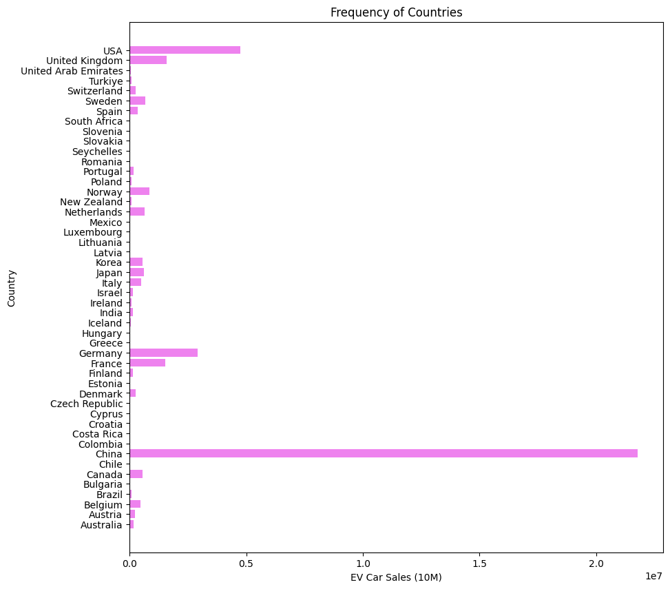

```
T-statistic: 1.4453343432604875
P-value: 0.11092828761768918
```

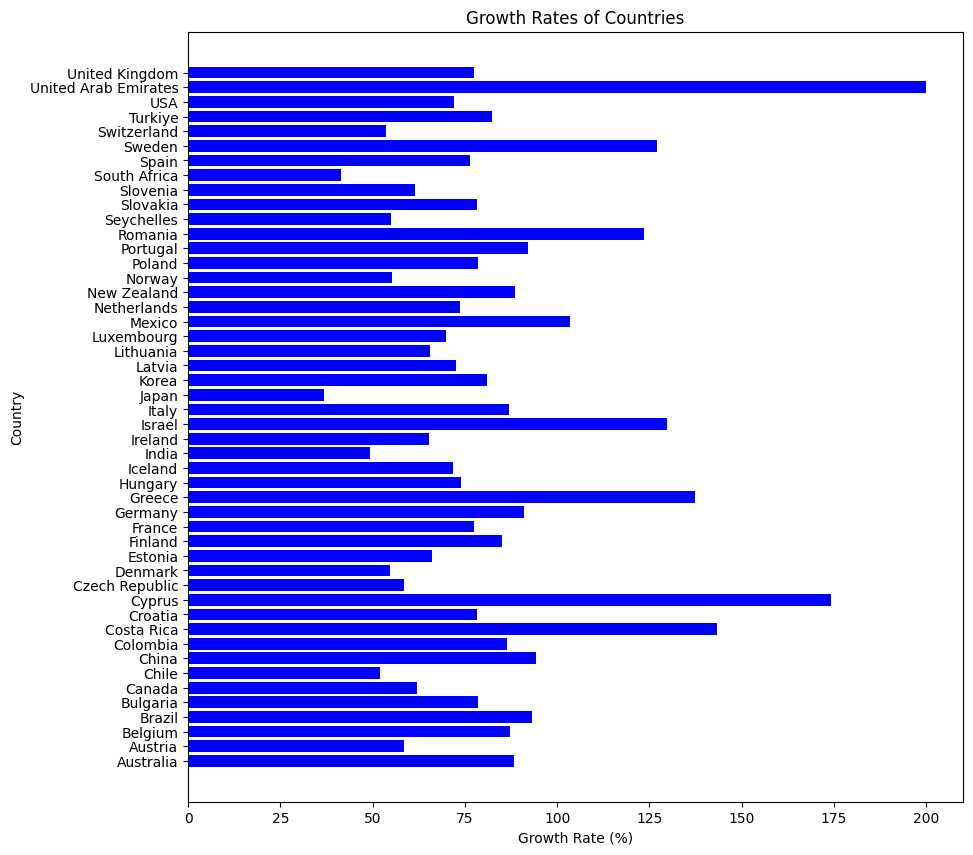

```
T-statistic: 1.9280651988260713
P-value: 0.029711834062448404
```

```python
# summing ev sales over time for each country
counts = []
for country in sales_df['region'].unique():
  counts.append(sales_df[sales_df['region'] == country]['value'].sum())
# plotting ev sales against country
plt.figure(figsize=(10, 10))
plt.barh(sales_df['region'].unique(), counts, color = 'violet')
plt.title('Frequency of Countries')
plt.xlabel('EV Car Sales (10M)')
plt.ylabel('Country')
plt.show()
# summing ev sales for top 5 GDP countries
topgppcountries = ["USA", "China", "Germany", "India", "Japan"]
topgdpcounts = []
for country in topgppcountries:
  topgdpcounts.append(sales_df[sales_df['region'] == country]['value'].sum())
# summing ev sales for other countries
othercounts = []
for country in sales_df['region'].unique():
  if country not in topgppcountries:
    othercounts.append(sales_df[sales_df['region'] == country]['value'].sum())
# finding out if difference is significant by performing two sample T-test
# no reason to assume variances are equal, so Welch's test
t_stat, p_value = ttest_ind(topgdpcounts, othercounts, equal_var=False, alternative='greater')
print("T-statistic:", t_stat)
print("P-value:", p_value)
plt.figure(figsize=(10, 10))
grouped = sales_df.groupby(['region', 'year'], as_index=False)['value'].sum()
grouped = grouped.sort_values(by = ['region', 'year'])
yeardiff = grouped.groupby('region')['year'].max() - grouped.groupby('region')['year'].min()
first_val = grouped.groupby('region')['value'].first()
last_val = grouped.groupby('region')['value'].last()
growth_rates = (last_val / first_val)**(1 / yeardiff) - 1
plt.figure(figsize=(10, 10))
plt.barh(growth_rates.index, growth_rates.values*100, color = 'blue')
plt.title('Growth Rates of Countries')
plt.xlabel('Growth Rate (%)')
plt.ylabel('Country')
plt.show()
# predict sales in 2023
predicted_sales = []
for country in sales_df['region'].unique():
  predicted_sales.append(growth_rates[country] * sales_df[(sales_df['region'] == country) & (sales_df['year'] == 2022)]['value'].sum() + sales_df[(sales_df['region'] == country) & (sales_df['year'] == 2022)]['value'].sum())
# actual sales in 2023
actual_sales = []
for country in topgppcountries:
  actual_sales.append(sales_df[(sales_df['region'] == country) & (sales_df['year'] == 2023)]['value'].sum())
# finding out if difference is significant
# we can assume equal variance since data is spread approximately the same
t_stat2, p_value2 = ttest_ind(actual_sales, predicted_sales, equal_var=True, alternative='greater')
print("T-statistic:", t_stat2)
print("P-value:", p_value2)
```

```python
import plotly.express as px

growth_rates_df = growth_rates.reset_index()
growth_rates_df.columns = ['region', 'growth_rate']

iso_mapping = {
    'Australia': 'AUS', 'Austria': 'AUT', 'Belgium': 'BEL', 'Brazil': 'BRA', 'Bulgaria': 'BGR',
    'Canada': 'CAN', 'Chile': 'CHL', 'China': 'CHN', 'Colombia': 'COL', 'Costa Rica': 'CRI',
    'Croatia': 'HRV', 'Cyprus': 'CYP', 'Czech Republic': 'CZE', 'Denmark': 'DNK', 'Estonia': 'EST',
    'Finland': 'FIN', 'France': 'FRA', 'Germany': 'DEU', 'Greece': 'GRC', 'Hungary': 'HUN',
    'Iceland': 'ISL', 'India': 'IND', 'Ireland': 'IRL', 'Israel': 'ISR', 'Italy': 'ITA',
    'Japan': 'JPN', 'Korea': 'KOR', 'Latvia': 'LVA', 'Lithuania': 'LTU', 'Luxembourg': 'LUX',
    'Mexico': 'MEX', 'Netherlands': 'NLD', 'New Zealand': 'NZL', 'Norway': 'NOR', 'Poland': 'POL',
    'Portugal': 'PRT', 'Romania': 'ROU', 'Seychelles': 'SYC', 'Slovakia': 'SVK', 'Slovenia': 'SVN',
    'South Africa': 'ZAF', 'Spain': 'ESP', 'Sweden': 'SWE', 'Switzerland': 'CHE', 'Turkiye': 'TUR',
    'USA': 'USA', 'United Arab Emirates': 'ARE', 'United Kingdom': 'GBR'
}

growth_rates_df['iso_alpha'] = growth_rates_df['region'].map(iso_mapping)
mapped_df = growth_rates_df.dropna(subset=['iso_alpha']).copy()

fig = px.choropleth(
    mapped_df,
    locations = 'iso_alpha',
    color = 'growth_rate',
    hover_name = 'region',
    color_continuous_scale = [(0.0, 'blue'), (1.0, 'red')],
    range_color = [mapped_df['growth_rate'].min(), mapped_df['growth_rate'].max()],
    title = 'Growth Rate of Car Sales by Country on World Map (Blue=Low, Red=High)',
    labels = {'growth_rate': 'growth_rate'}
)

fig.update_layout(
    geo = dict(
        showframe = False,
        showcoastlines = True,
        projection_type = 'natural earth',
        bgcolor = 'white'
    ),
    title_x = 0.5,
    width = 1200,
    height = 700
)

fig.update_coloraxes(
    colorbar_title = "Growth Rate",
)

fig.show()
```

[interactive chart not shown]

The two-sample t-test comparing the total EV sales from 2010 to 2023 in the top 5 countries with the highest GDPs to the rest of the countries' sales in those years yielded a t-statistic value of 1.45 and a p-value of 0.11. The p-value is greater that 0.05 and the t-statistic value is relatively small, so the null hypothesis is accepted. Thus, our assumption was incorrect and there is no significant different between the total sales for top GDP countries and other countries. Looking at the first bar graph, it can be observed that China is an outlier and has high sales, but other high GDP countries do not have much more sales than other countries.

# **Comparing Sales Growth of Recorded EV Types**

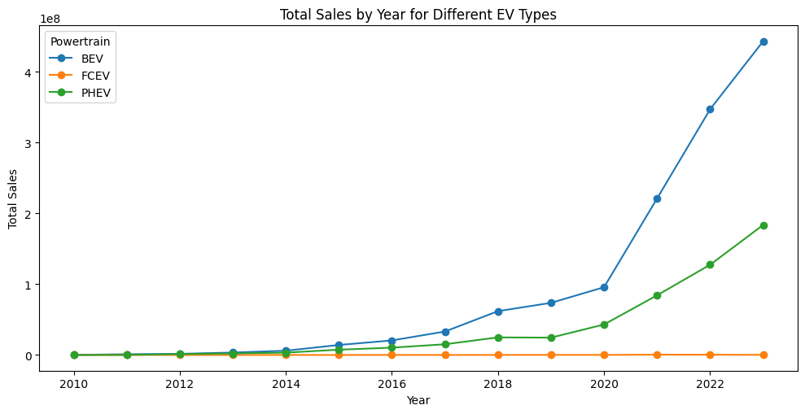

```python
powertrain_df = sales_df.copy()
powertrain_df_total = powertrain_df.groupby(['powertrain', 'year'])['value'].sum().reset_index()
powertrain_df_total.rename(columns={'value': 'total_sales'}, inplace = True)
powertrain_df = powertrain_df.merge(powertrain_df_total, on = ['powertrain', 'year'])
powertrain_df.drop(columns = ['value', 'region'], inplace = True)
powertrain_df.drop_duplicates()

grouped_EV_type = powertrain_df.groupby(['year', 'powertrain'], as_index = False)['total_sales'].sum()

plt.figure(figsize=(10, 5.2))

for powertrain in grouped_EV_type['powertrain'].unique():
    powertrain_data = grouped_EV_type[grouped_EV_type['powertrain'] == powertrain]
    plt.plot(powertrain_data['year'], powertrain_data['total_sales'], marker = 'o', label = powertrain)

plt.xlabel('Year')
plt.ylabel('Total Sales')
plt.title('Total Sales by Year for Different EV Types')
plt.legend(title = 'Powertrain')
plt.tight_layout()
plt.show()
```

The reorganized data table for this graph considers the total number of sales for each EV type on a yearly basis, summing all sales of the same EV type from the recorded countries in the dataset.

BEV (Battery Electric Vehicles) cars have the most sales by a wide margin, with PHEV (Plug-in Hybrid Electric Vehicles) as the second most popular. FCEV (Fuel Cell Electric Vehicles) are far less popular, but still have an upward trend in sales towards more recent years.

# *Correlation of EV Type Sales Growth*

While the format of our cleaned sales_df dataset does not show the correlation between the sales growth of different EV types, reorganizing the dataframe allows us to see how these sales are correlated through a correlation matrix.

We can assume the null hypothesis to be the assumption that there is a strong positive correlation between all EV types, as an increase in EV sales in general may increase sales for all types of EVs, presumably as a similar rate.

Thus, our alternative hypothesis is that the sales of at least one pair of EV types do not have a strong poitive correlation, and that our assumed trend of EV sales types is incorrect.

```python
type_cor_df = sales_df.copy()
type_cor_result = type_cor_df.pivot_table(
    index=['region', 'year'],
    columns='powertrain',
    values='value',
    fill_value = 0
).reset_index()
type_cor_result = type_cor_result[['region', 'BEV', 'PHEV', 'FCEV', 'year']]

correlation_matrix = type_cor_result[['BEV', 'PHEV', 'FCEV']].corr()
correlation_matrix
```

| powertrain | BEV | PHEV | FCEV |
| --- | --- | --- | --- |
| BEV | 1.000000 | 0.957534 | 0.098457 |
| PHEV | 0.957534 | 1.000000 | 0.078035 |
| FCEV | 0.098457 | 0.078035 | 1.000000 |

There appears to be a strong correlation between BEV and PHEV type sales worldwide. BEV and FCEV have a minimal positive correlation, with PHEV and FCEV having practically no positive correlation. As a result, our alternative hypothesis was proven correct-- not all EV types have a distinct positive correlation.

# **Top 10 GDP Countries 2025 EV Sales from 2010-2023**

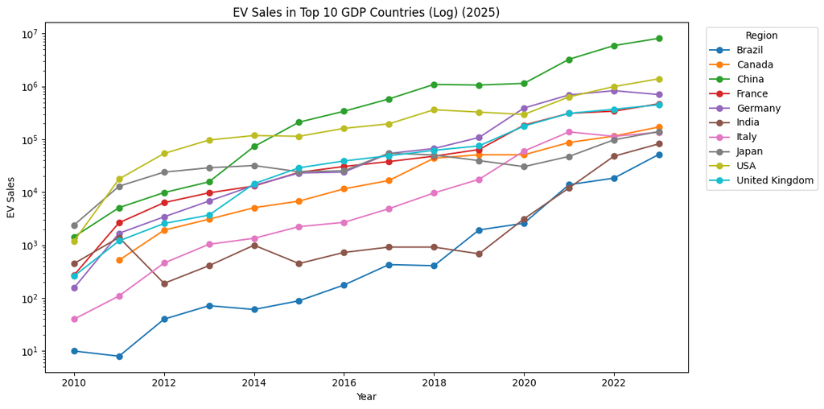

```python
top10_gdp = [
    'USA', 'China', 'Germany', 'India', 'Japan',
    'United Kingdom', 'France', 'Italy', 'Canada', 'Brazil'
]

import matplotlib.pyplot as plt

ev_df = sales_df.copy()
ev_df = ev_df[ev_df['region'].isin(top10_gdp)]

grouped = ev_df.groupby(['region', 'year'], as_index=False)['value'].sum()
ev_agg = grouped.rename(columns={'value': 'ev_sales'})

ev_pivot = ev_agg.pivot(index='year', columns='region', values='ev_sales').fillna(0)

plt.figure(figsize=(12, 6))

for region in ev_agg['region'].unique():
    region_data = ev_agg[ev_agg['region'] == region]
    plt.plot(
        region_data['year'],
        region_data['ev_sales'],
        marker='o',
        label=region
    )

plt.xlabel('Year')
plt.ylabel('EV Sales')
plt.title('EV Sales in Top 10 GDP Countries (Log) (2025)')
plt.yscale('log')
plt.legend(title='Region', bbox_to_anchor=(1.02, 1), loc='upper left')
plt.tight_layout()
plt.show()
```

The log-scale graph shows EV sales from 2010 to 2023 in the top 10 GDP countries and helps highlight differences in how quickly each country’s EV market has grown. Using a logarithmic scale makes it easier to see trends in countries with lower overall sales, like Brazil, India, and Italy, which usually get compressed in regular line graphs. While China’s massive spike in sales after 2019 is still clear, the log scale smooths out the curve a bit, making it easier to spot steady growth in countries like the UK, France, and Canada. Overall, the log graph is a helpful way to compare how quickly each country is growing in EV adoption, rather than just focusing on which ones sold the most.

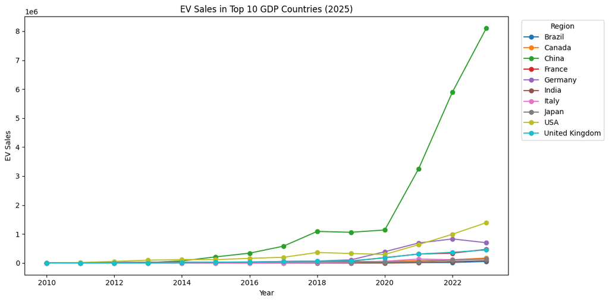

```python
plt.figure(figsize=(12, 6))
for region in ev_agg['region'].unique():
    region_data = ev_agg[ev_agg['region'] == region]
    plt.plot(
        region_data['year'],
        region_data['ev_sales'],
        marker = 'o',
        label = region
    )
plt.xlabel('Year')
plt.ylabel('EV Sales')
plt.title('EV Sales in Top 10 GDP Countries (2025)')
plt.legend(title = 'Region', bbox_to_anchor = (1.02, 1), loc = 'upper left')
plt.tight_layout()
plt.show()
```

As shown in the graph, China leads by a significant margin, with exponential growth in EV sales beginning around 2020. The United States follows with steady growth, particularly post-2021. European nations such as Germany, France, and the UK show moderate but consistent increases. In contrast, countries like Brazil and India lag behind, reflecting slower adoption or limited infrastructure. This disparity underscores how economic scale doesn't always correlate with EV adoption and highlights the impact of national policy and infrastructure on the EV market.

**Summary of Visuals Top 10 GDP Countries**

Both the linear and logarithmic versions of the EV sales graph offer complementary insights into global adoption patterns among the top 10 GDP countries. The linear graph highlights absolute differences, with China visibly dominating in total EV sales, followed by the USA. However, it compresses the data for countries with lower sales volumes, making it harder to evaluate their trends.

In contrast, the log-scale graph provides a clearer view of relative growth, making it easier to see how nations like India, Brazil, and Italy are gradually scaling their EV markets despite having lower starting points. It helps emphasize that while the gap in absolute numbers remains large, many countries are showing consistent and promising exponential growth. These two graphs paint a fuller picture: one of China's clear leadership in sales, and another of emerging EV markets with a strong rate.

# **Exploring Volatility Calculation and Visualization**

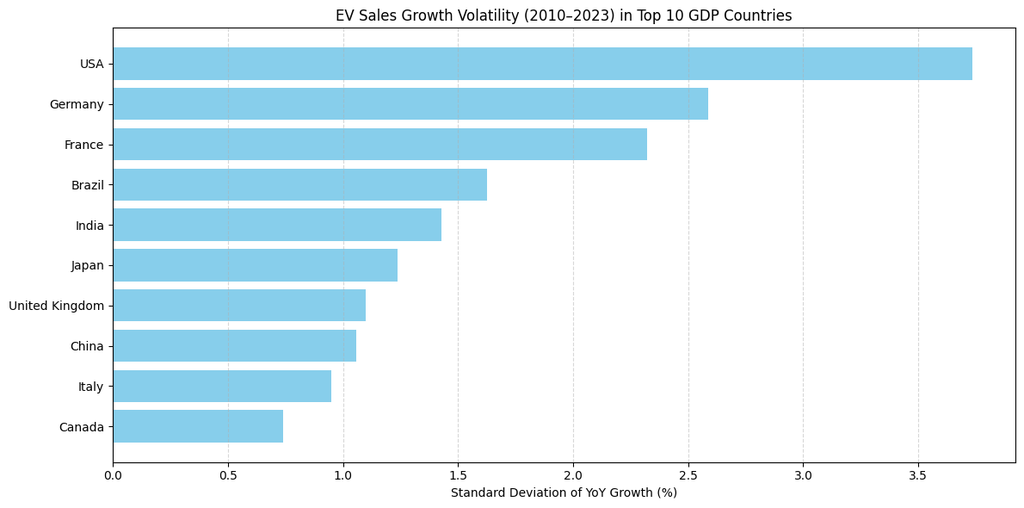

```python
ev_agg['pct_change'] = ev_agg.groupby('region')['ev_sales'].pct_change()

volatility = ev_agg.groupby('region')['pct_change'].std().reset_index()
volatility.columns = ['region', 'volatility']
volatility = volatility.sort_values(by='volatility', ascending=False)

plt.figure(figsize=(12, 6))

volatility_sorted = volatility.sort_values('volatility', ascending=True)

plt.barh(
    volatility_sorted['region'],
    volatility_sorted['volatility'],
    color='skyblue'
)
plt.xlabel('Standard Deviation of YoY Growth (%)')
plt.title('EV Sales Growth Volatility (2010–2023) in Top 10 GDP Countries')
plt.grid(axis='x', linestyle='--', alpha=0.5)
plt.tight_layout()
plt.show()
```

**Volatility** in this context refers to the **consistency (or inconsistency)** in a country's year-over-year (YoY) electric vehicle (EV) sales growth. It's measured using the **standard deviation** of the annual percentage change in EV sales from 2010 to 2023.

- A **higher standard deviation** means the country's EV sales growth has fluctuated more, indicating an **unstable growth pattern.**
- A **lower standard deviation** suggests that the country has experienced **steadier growth** year to year.

- The **United States** has the **highest volatility**, meaning its annual EV growth has varied widely — possibly due to shifts in policy, consumer demand, or manufacturer output.
- **Germany** and **France** also show relatively high volatility, reflecting some inconsistency in how their EV markets have grown over the years.
- On the other end, **Canada, Italy**, and **China** show the **lowest volatility**, suggesting that their EV markets have grown at a more consistent pace.

```python
from scipy.stats import f_oneway

ev_agg['pct_change'] = ev_agg.groupby('region')['ev_sales'].pct_change()

ev_agg_top10 = ev_agg[ev_agg['region'].isin(top10_gdp)]

anova_groups = [ev_agg_top10[ev_agg_top10['region'] == country]['pct_change'].dropna()
                for country in top10_gdp]

f_stat, p_value = f_oneway(*anova_groups)
print("F-statistic:", f_stat)
print("P-value:", p_value)
```

```
F-statistic: 0.3203388713247266
P-value: 0.9669424302874488
```

The F-statistic is very low, and the corresponding p-value is substantially higher than the common significance threshold (e.g., 0.05). This indicates no statistically significant difference in the mean year-over-year EV sales growth rates among the top 10 GDP countries.

In simpler terms, while the earlier volatility analysis (using standard deviation) showed that some countries have more fluctuating growth patterns than others, the overall average percentage growth rates are statistically similar across these countries over the period from 2010 to 2023.

Thus, although the magnitude of fluctuations (volatility) varies, the ANOVA suggests there is no evidence to conclude that the average YoY growth rates are fundamentally different among these nations.

# 🔍 **ML Forecasting by Country and Powertrain**

This section focuses on modeling electric vehicle (EV) sales trends in the world’s top 10 GDP countries, across three major powertrain types: Battery Electric Vehicles (BEV), Plug-in Hybrid Electric Vehicles (PHEV), and Fuel Cell Electric Vehicles (FCEV). For each country, the dataset is filtered by powertrain, and a linear regression model is fitted to the historical EV sales data from 2010 to 2023. These models are then used to predict EV sales for the year 2024.

Each country’s results are visualized using three side-by-side plots—one for each powertrain. The plots show yellow scatter points for the actual historical sales and a blue trend line generated by the trained model. The predicted value for 2024 is printed below each set of graphs, giving a quick comparison of expected EV sales across different technologies and countries.

**📈 Machine Learning Details**

For every (country, powertrain) combination:

- A Linear Regression model is trained to capture the relationship between year (independent variable) and EV sales (dependent variable).
- This model is part of supervised learning, where the algorithm learns from labeled data to make future predictions.
- After training, each model is used to forecast the number of EVs expected to be sold in 2024.
- This setup allows us to identify both global trends and local adoption patterns, offering a data-driven view into how EV markets are expected to evolve.
- This method provides valuable insights into market momentum, highlighting where EV adoption is accelerating and which powertrain types are gaining traction across different regions.

📚 Additional Resource: For more background on how linear regression works in machine learning, see [GeeksforGeeks – Linear Regression in ML](https://www.geeksforgeeks.org/machine-learning/ml-linear-regression/)

# **Regression Model - Countries**

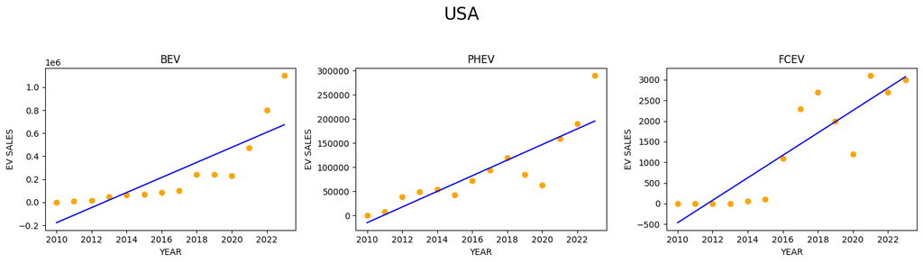

```
2024 Predictions for USA
BEV: 738608.79
PHEV: 212164.84
FCEV: 3343.35
```

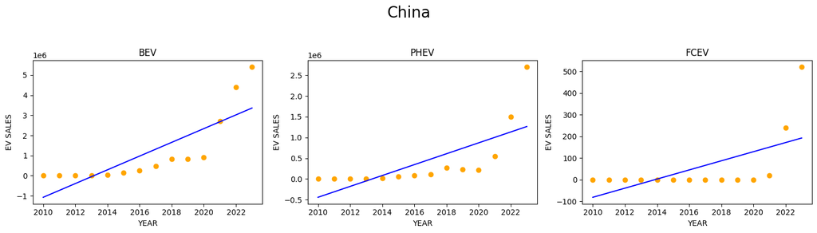

```
2024 Predictions for China
BEV: 3703313.19
PHEV: 1395501.54
FCEV: 213.41
```

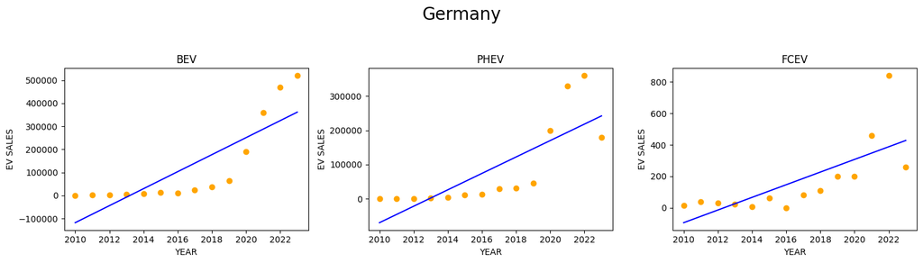

```
2024 Predictions for Germany
BEV: 398416.26
PHEV: 266246.15
FCEV: 467.92
```

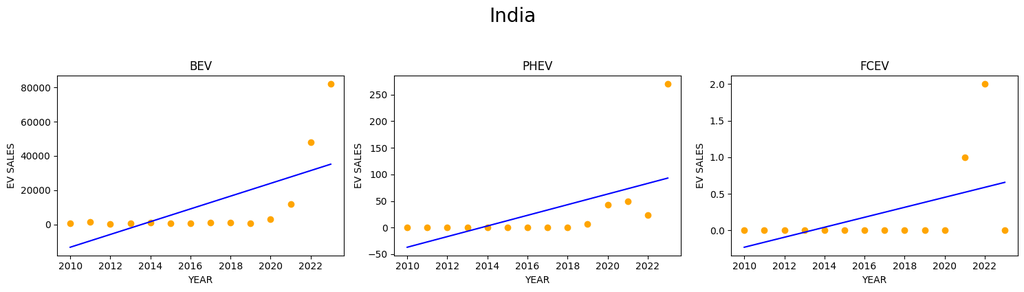

```
2024 Predictions for India
BEV: 38861.87
PHEV: 103.05
FCEV: 0.73
```

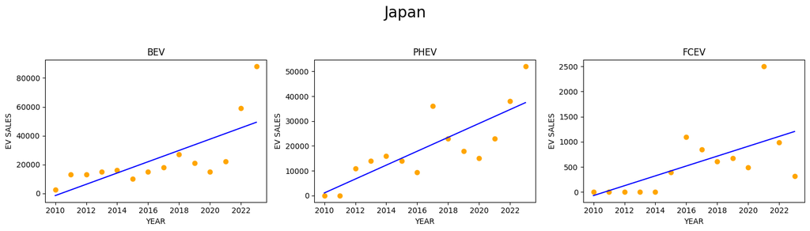

```
2024 Predictions for Japan
BEV: 53206.59
PHEV: 40218.13
FCEV: 1302.57
```

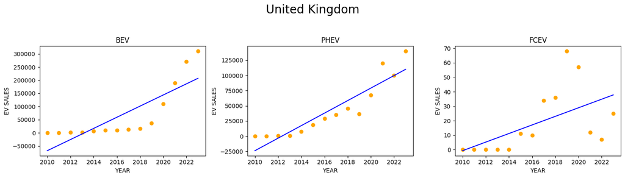

```
2024 Predictions for United Kingdom
BEV: 228423.96
PHEV: 120479.86
FCEV: 40.79
```

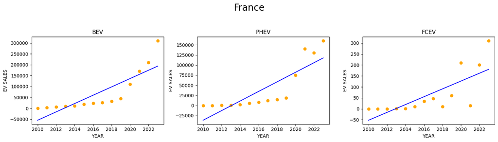

```
2024 Predictions for France
BEV: 213154.18
PHEV: 129558.84
FCEV: 197.95
```

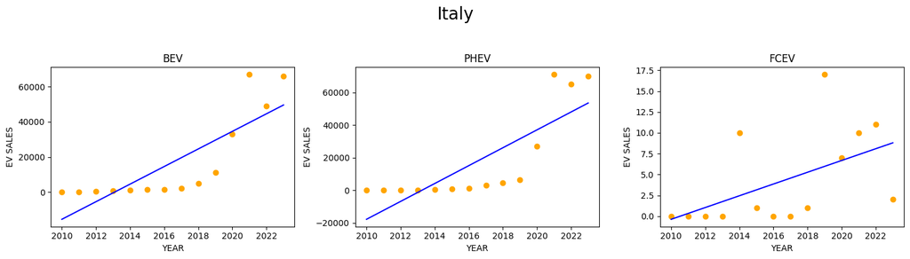

```
2024 Predictions for Italy
BEV: 54612.31
PHEV: 58976.04
FCEV: 9.51
```

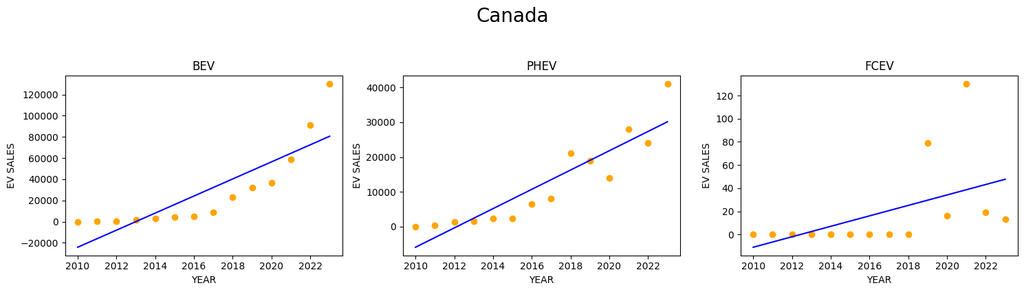

```
2024 Predictions for Canada
BEV: 88699.56
PHEV: 32894.51
FCEV: 52.23
```

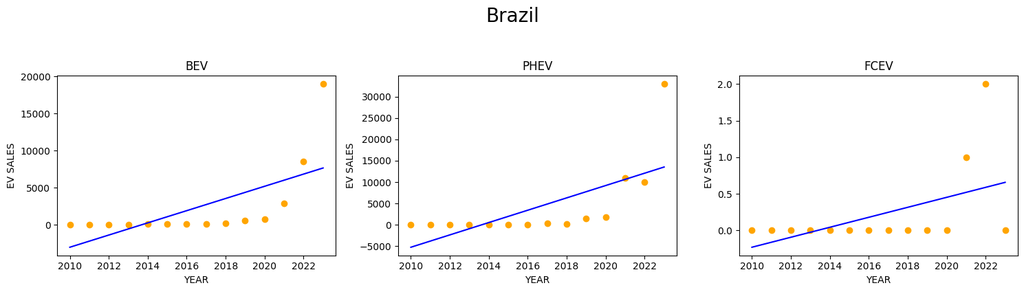

```
2024 Predictions for Brazil
BEV: 8482.98
PHEV: 14978.93
FCEV: 0.73
```

```python
import matplotlib.pyplot as plt
from sklearn.linear_model import LinearRegression
import pandas as pd

top10_gdp = [
    'USA', 'China', 'Germany', 'India', 'Japan',
    'United Kingdom', 'France', 'Italy', 'Canada', 'Brazil'
]

power_trains = ['BEV', 'PHEV', 'FCEV']
years = list(range(2010, 2024))  # 2010–2023

for country in top10_gdp:
    fig, axes = plt.subplots(1, 3, figsize=(15, 4))
    fig.suptitle(country, fontsize=20, y=1.05)
    predictions_2024 = []

    for i, power in enumerate(power_trains):
        # Filter original data
        df = sales_df[(sales_df['region'] == country) & (sales_df['powertrain'] == power)]

        # Create full year range with zero or NaN if missing
        full_years_df = pd.DataFrame({'year': years})
        merged_df = pd.merge(full_years_df, df[['year', 'value']], on='year', how='left')
        merged_df['value'] = merged_df['value'].fillna(0)  # or use interpolation if preferred

        x = merged_df[['year']]
        y = merged_df['value']

        model = LinearRegression()
        model.fit(x, y)
        predictions = model.predict(x)

        # Predict for 2024
        prediction_2024 = model.predict(pd.DataFrame({'year': [2024]}))[0]
        predictions_2024.append(prediction_2024)

        # Plot
        axes[i].scatter(x, y, color='orange')
        axes[i].plot(x, predictions, color='blue')
        axes[i].set_title(power)
        axes[i].set_xlabel('YEAR')
        axes[i].set_ylabel('EV SALES')

    plt.tight_layout()
    plt.show()

    print("2024 Predictions for", country)
    for i in range(3):
        print(f"{power_trains[i]}: {predictions_2024[i]:.2f}")
```

# **Regression Model - Global Scale**

This code performs a global analysis of electric vehicle (EV) sales by aggregating the dataset across all countries based on year and powertrain type. It focuses on three major EV categories: BEV (Battery Electric Vehicles), PHEV (Plug-in Hybrid Electric Vehicles), and FCEV (Fuel Cell Electric Vehicles). For each powertrain, a linear regression model is trained using historical worldwide sales data to identify trends and forecast sales for the year 2024. The model takes the year as the input feature and total global EV sales as the target variable. The results are visualized using three side-by-side subplots, each showing the actual data points (in yellow) and the fitted regression line (in blue) for one powertrain type. After the plots are displayed, the code prints the predicted sales figures for 2024, offering a simple yet insightful projection of global EV market growth by technology type.

**Modeling Approach**

The modeling approach used in this analysis is based on linear regression, a supervised machine learning technique that models the relationship between a continuous dependent variable and one or more independent variables. In this case, the independent variable is the year, and the dependent variable is the total EV sales for each powertrain type. For each powertrain (BEV, PHEV, FCEV), a separate linear model is trained on the aggregated historical global sales data. The assumption is that past trends in EV adoption can be approximated by a linear growth pattern over time. Once trained, each model is used to predict the expected sales for the year 2024. This approach provides a straightforward and interpretable way to forecast future sales, serving as a baseline for understanding EV adoption trends globally.

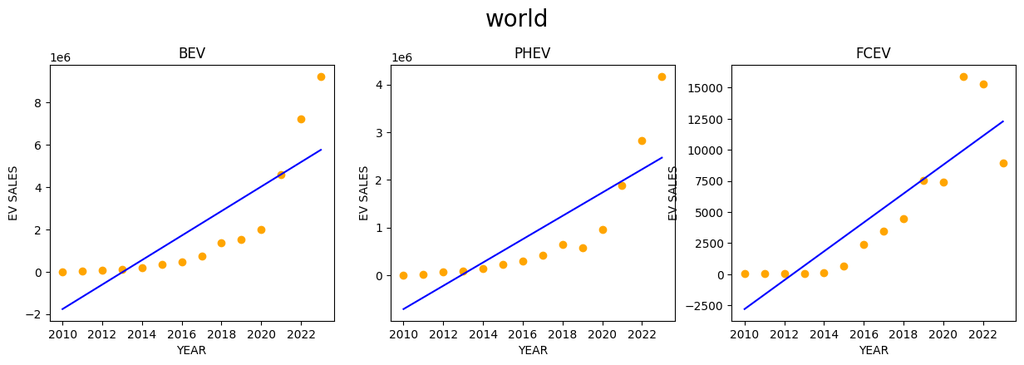

```
2024 Predictions
BEV: [6333429.01098919]
PHEV: [2708519.59340656]
FCEV: [13447.37142857]
```

```python
grouped = sales_df.groupby(['year', 'powertrain'])['value'].sum().reset_index()
power_trains = ['BEV', 'PHEV', 'FCEV']

fig, axes = plt.subplots(1, 3, figsize=(15, 4))  # 1 row, 3 columns
fig.suptitle('world', fontsize = 20, y = 1.05)
predictions_2024 = []
for i in range(len(power_trains)):
  power = power_trains[i]
  df = grouped[grouped['powertrain']==power]
  if len(df)==0:
    continue
  x = df[['year']]
  y = df['value']
  model = LinearRegression()
  model.fit(x,y)
  predictions = model.predict(x)
  new_data = pd.DataFrame({'year': [2024]})
  predictions_2024.append(model.predict(new_data))
  axes[i].scatter(x,y,color='orange')
  axes[i].plot(x, predictions,color= 'blue')
  axes[i].set_title(power)
  axes[i].set_xlabel('YEAR')
  axes[i].set_ylabel('EV SALES')
plt.show()
print("2024 Predictions")
for i in range(3):
  print(power_trains[i] + ": "+str(predictions_2024[i]))
```

# **Attempting Additional Regressions**

Our code will print the overlapping graphs, the best fit regression and the 2023 squared error.

```
USA - BEV: Best Fit = Polynomial,
     2023 MSE = 92,308,037,143
USA - PHEV: Best Fit = Polynomial,
     2023 MSE = 11,859,666,927
USA - FCEV: Best Fit = Linear,
     2023 MSE = 9,246
```

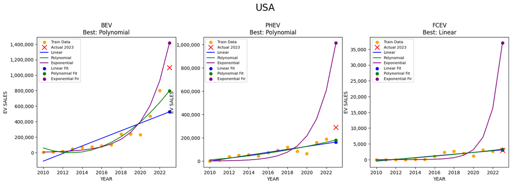

```
China - BEV: Best Fit = Polynomial,
     2023 MSE = 861,437,109,468
China - PHEV: Best Fit = Polynomial,
     2023 MSE = 1,882,517,556,487
China - FCEV: Best Fit = Polynomial,
     2023 MSE = 119,078
```

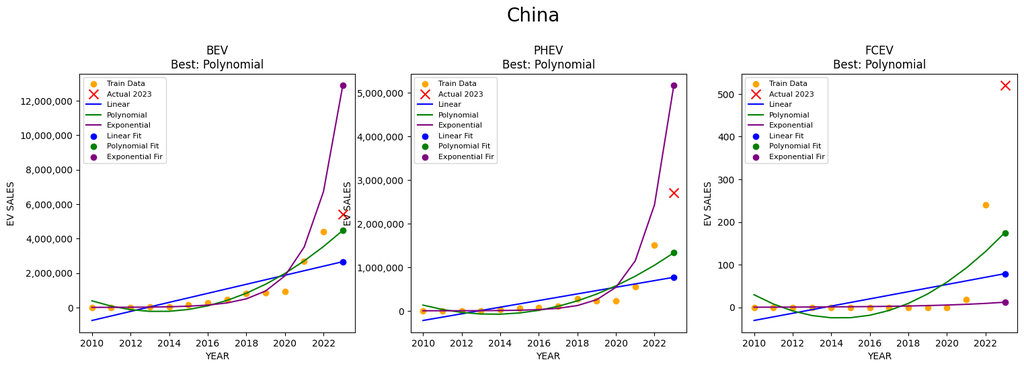

```
Germany - BEV: Best Fit = Polynomial,
     2023 MSE = 352,473,054
Germany - PHEV: Best Fit = Linear,
     2023 MSE = 7,019,088,400
Germany - FCEV: Best Fit = Exponential,
     2023 MSE = 37,812
```

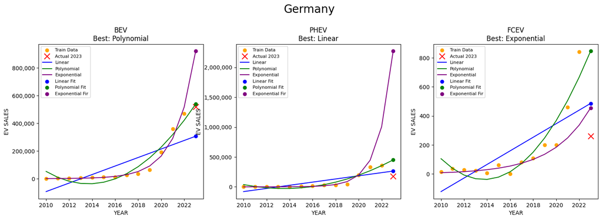

```
India - BEV: Best Fit = Polynomial,
     2023 MSE = 1,822,286,837
India - PHEV: Best Fit = Polynomial,
     2023 MSE = 47,891
India - FCEV: Best Fit = Linear,
     2023 MSE = 1
```

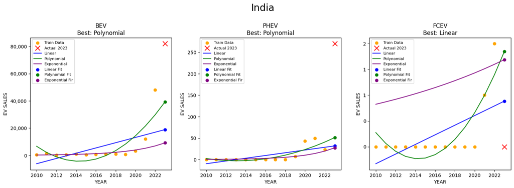

```
Japan - BEV: Best Fit = Polynomial,
     2023 MSE = 1,720,103,117
Japan - PHEV: Best Fit = Linear,
     2023 MSE = 385,133,077
Japan - FCEV: Best Fit = Linear,
     2023 MSE = 1,417,565
```

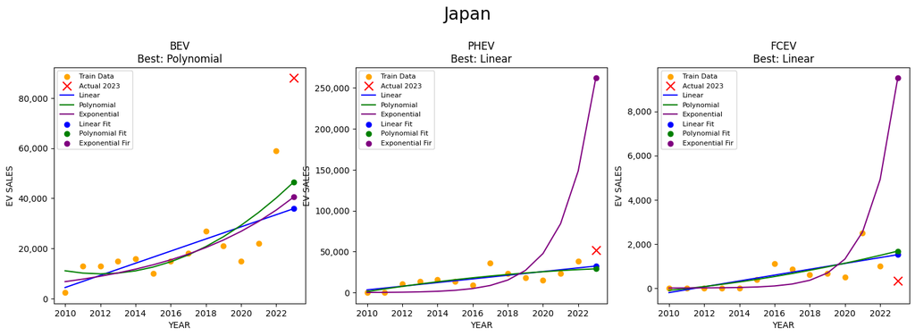

```
United Kingdom - BEV: Best Fit = Polynomial,
     2023 MSE = 81,982,261
United Kingdom - PHEV: Best Fit = Polynomial,
     2023 MSE = 69,000,324
United Kingdom - FCEV: Best Fit = Polynomial,
     2023 MSE = 0
```

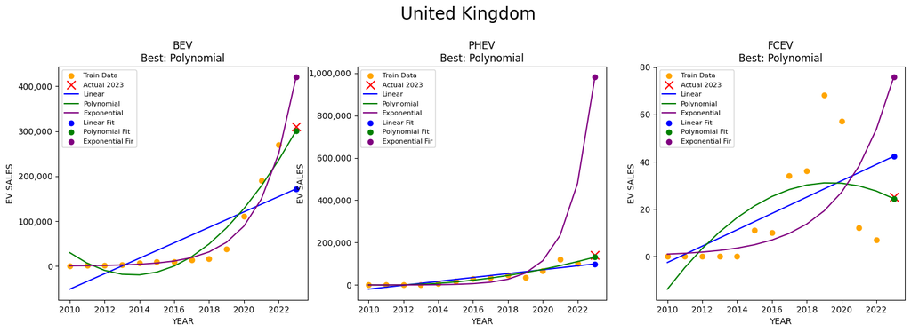

```
France - BEV: Best Fit = Polynomial,
     2023 MSE = 4,369,422,632
France - PHEV: Best Fit = Polynomial,
     2023 MSE = 144,766,668
France - FCEV: Best Fit = Exponential,
     2023 MSE = 3,098
```

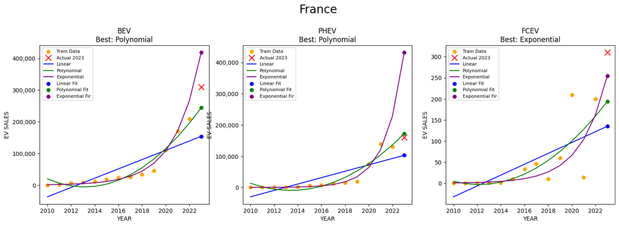

```
Italy - BEV: Best Fit = Polynomial,
     2023 MSE = 58,334,344
Italy - PHEV: Best Fit = Polynomial,
     2023 MSE = 217,940,181
Italy - FCEV: Best Fit = Linear,
     2023 MSE = 84
```

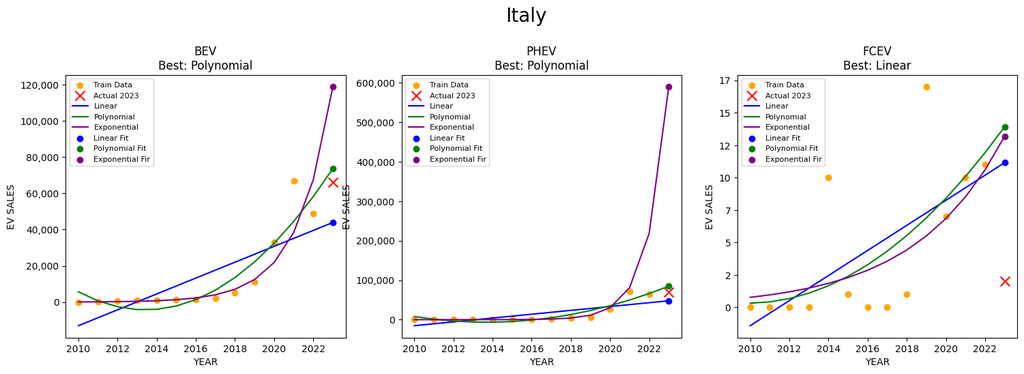

```
Canada - BEV: Best Fit = Polynomial,
     2023 MSE = 926,585,085
Canada - PHEV: Best Fit = Polynomial,
     2023 MSE = 85,258,749
Canada - FCEV: Best Fit = Exponential,
     2023 MSE = 824
```

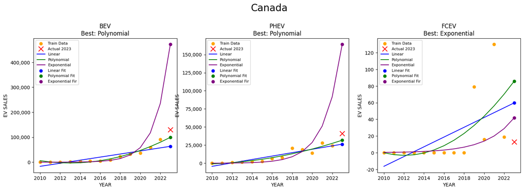

```
Brazil - BEV: Best Fit = Polynomial,
     2023 MSE = 133,958,447
Brazil - PHEV: Best Fit = Exponential,
     2023 MSE = 111,049,118
Brazil - FCEV: Best Fit = Linear,
     2023 MSE = 1
```

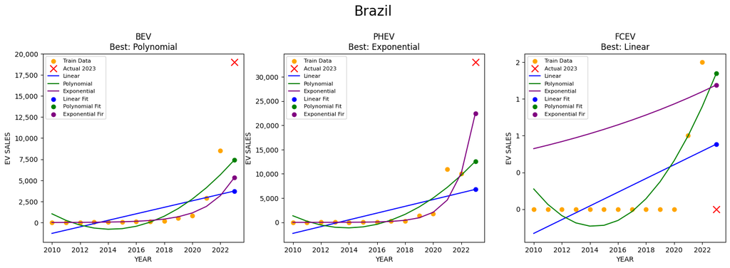

```python
import numpy as np
import pandas as pd
import matplotlib.pyplot as plt
from sklearn.linear_model import LinearRegression
from sklearn.preprocessing import PolynomialFeatures

top10_gdp = ['USA', 'China', 'Germany', 'India', 'Japan', 'United Kingdom', 'France', 'Italy', 'Canada', 'Brazil']
power_trains = ['BEV', 'PHEV', 'FCEV']

for country in top10_gdp:
    fig, axes = plt.subplots(1, 3, figsize=(18, 5))
    fig.suptitle(country, fontsize=20, y=1.08)
    for i, power in enumerate(power_trains):
        df = sales_df[(sales_df['region'] == country) & (sales_df['powertrain'] == power)]

        # Ensure data starts from 2010 to 2023 (training data only)
        full_years = pd.DataFrame({'year': list(range(2010, 2024))})
        df = pd.merge(full_years, df[['year', 'value']], on='year', how='left')
        df['value'] = df['value'].fillna(0)  # or use interpolate() if you prefer

        df_fit = df[df['year'] <= 2022]
        df_2023 = df[df['year'] == 2023]
        if len(df_fit) == 0 or len(df_2023) == 0:
            axes[i].set_title(f"{power}\nNo Data")
            axes[i].axis('off')
            continue
        x = df_fit[['year']]
        y = df_fit['value'].values
        x_plot = pd.DataFrame({'year': np.arange(x['year'].min(), 2024)})
        # Linear
        lin_model = LinearRegression()
        lin_model.fit(x, y)
        lin_pred_2023 = lin_model.predict(pd.DataFrame({'year': [2023]}))[0]
        lin_fit = lin_model.predict(x_plot)
        # Polynomial (degree=2)
        poly = PolynomialFeatures(degree=2, include_bias=False)
        x_poly = poly.fit_transform(x)
        poly_model = LinearRegression()
        poly_model.fit(x_poly, y)
        poly_pred_2023 = poly_model.predict(poly.transform(pd.DataFrame({'year': [2023]})))[0]
        poly_fit = poly_model.predict(poly.transform(x_plot))
        # Exponential
        log_y = np.log(y+1)
        exp_model = LinearRegression()
        exp_model.fit(x, log_y)
        exp_pred_2023 = np.exp(exp_model.predict(pd.DataFrame({'year': [2023]})))[0]
        exp_fit = np.exp(exp_model.predict(x_plot))

        actual_2023 = df_2023['value'].values[0]
        # Error (MSE)
        errors = {'Linear': abs(lin_pred_2023 - actual_2023) ** 2,
                  'Polynomial': abs(poly_pred_2023 - actual_2023) ** 2,
                  'Exponential': abs(exp_pred_2023 - actual_2023) ** 2}
        percent_errors = {'Linear': abs(lin_pred_2023 - actual_2023) / abs(actual_2023) * 100,
                          'Polynomial': abs(poly_pred_2023 - actual_2023) / abs(actual_2023) * 100,
                          'Exponential': abs(exp_pred_2023 - actual_2023) / abs(actual_2023) * 100}
        best_fit = min(errors, key=errors.get)

        axes[i].scatter(x, y, color='orange', label='Train Data')
        axes[i].scatter([2023], [actual_2023], color='red', marker='x', s=100, label='Actual 2023')
        axes[i].plot(x_plot, lin_fit, color='blue', label='Linear')
        axes[i].plot(x_plot, poly_fit, color='green', label='Polynomial')
        axes[i].plot(x_plot, exp_fit, color='purple', label='Exponential')
        axes[i].scatter([2023], [lin_pred_2023], color='blue', marker='o', label='Linear Fit')
        axes[i].scatter([2023], [poly_pred_2023], color='green', marker='o', label='Polynomial Fit')
        axes[i].scatter([2023], [exp_pred_2023], color='purple', marker='o', label='Exponential Fit')
        axes[i].set_title(f"{power}\nBest: {best_fit}")
        axes[i].set_xlabel('YEAR')
        axes[i].set_ylabel('EV SALES')
        axes[i].yaxis.set_major_formatter(plt.FuncFormatter(lambda x, _: f'{int(x):,}'))
        axes[i].legend(fontsize=8)
        # 2024 Prediction
        if best_fit == 'Linear':
            pred_2024 = lin_model.predict(pd.DataFrame({'year': [2024]}))[0]
        elif best_fit == 'Polynomial':
            pred_2024 = poly_model.predict(poly.transform(pd.DataFrame({'year': [2024]})))[0]
        elif best_fit == 'Exponential':
            pred_2024 = np.exp(exp_model.predict(pd.DataFrame({'year': [2024]})))[0]
        print(f"{country} - {power}: Best Fit = {best_fit}, \n     "
              f"2023 MSE = {errors[best_fit]:,.0f} "
              #f"2023 Percent Error = {percent_errors[best_fit]:.2f}%, \n     "
              #f"2024 {best_fit} Prediction: {pred_2024:,.0f} {power} Sales")
        )
    plt.show()
```

Despite the exponential-like trend at which the sales of these countries grow, the best fit is often the polynomial line. So the distribution of points is neither a clear linear of exponential set of points. It can be extrapolated, then, that the sales of EV cars in the top 10 highest GDP countries will continuously grow at this polynomial rate. Because polynomial regression often fits datasets that have distinct changes in growth rate, this implies that the growth rate of these countries' sales may increase further in the future, due to the rapid increase around the 2020.

# 🧪 **Model Accuracy Check: 2023 Predictions vs Actuals**

In this section, we tested how well our polynomial regression model performs by predicting EV sales for 2023 and comparing those predictions to the actual reported values. We trained the model using data up to 2022, then made predictions for 2023 and calculated the percent error for each country and powertrain.

```python
for country in top10_gdp:
    print(f"\n--- {country} ---")
    for power in power_trains:
        df = sales_df[(sales_df['region'] == country) & (sales_df['powertrain'] == power)]

        if 2023 not in df['year'].values or len(df) < 5:
            continue

        train = df[df['year'] < 2023]
        test_2023 = df[df['year'] == 2023]['value'].values[0]

        x_train = train[['year']]
        y_train = np.log(train['value'].values)

        poly = PolynomialFeatures(degree=2, include_bias=False)
        x_train_poly = poly.fit_transform(x_train)

        model = LinearRegression()
        model.fit(x_train_poly, y_train)

        x_2023_df = pd.DataFrame({'year': [2023]})
        x_2024_df = pd.DataFrame({'year': [2024]})

        x_2023 = poly.transform(x_2023_df)
        x_2024 = poly.transform(x_2024_df)

        pred_2023_log = model.predict(x_2023)[0]
        pred_2024_log = model.predict(x_2024)[0]

        pred_2023 = np.exp(pred_2023_log)
        pred_2024 = np.exp(pred_2024_log)

        error_pct = abs(pred_2023 - test_2023) / test_2023 * 100

        print(f"{power} | 2023 predicted: {int(pred_2023):,}, actual: {int(test_2023):,}, error: {error_pct:.2f}%")
        print(f"{power} | 2024 forecast: {int(pred_2024):,}")
```

```
--- USA ---
BEV | 2023 predicted: 490,443, actual: 1,100,000, error: 55.41%
BEV | 2024 forecast: 475,650
PHEV | 2023 predicted: 130,419, actual: 290,000, error: 55.03%
PHEV | 2024 forecast: 123,176
FCEV | 2023 predicted: 953, actual: 3,000, error: 68.20%
FCEV | 2024 forecast: 398

--- China ---
BEV | 2023 predicted: 3,988,420, actual: 5,400,000, error: 26.14%
BEV | 2024 forecast: 4,625,019
PHEV | 2023 predicted: 1,130,035, actual: 2,700,000, error: 58.15%
PHEV | 2024 forecast: 1,251,951

--- Germany ---
BEV | 2023 predicted: 628,727, actual: 520,000, error: 20.91%
BEV | 2024 forecast: 950,934
PHEV | 2023 predicted: 583,695, actual: 180,000, error: 224.28%
PHEV | 2024 forecast: 870,237
FCEV | 2023 predicted: 1,724, actual: 260, error: 563.35%
FCEV | 2024 forecast: 3,641

--- India ---
BEV | 2023 predicted: 75,590, actual: 82,000, error: 7.82%
BEV | 2024 forecast: 248,416
PHEV | 2023 predicted: 2, actual: 270, error: 99.11%
PHEV | 2024 forecast: 0

--- Japan ---
BEV | 2023 predicted: 32,228, actual: 88,000, error: 63.38%
BEV | 2024 forecast: 33,518
PHEV | 2023 predicted: 6,106, actual: 52,000, error: 88.26%
PHEV | 2024 forecast: 2,476
FCEV | 2023 predicted: 1,340, actual: 320, error: 318.92%
FCEV | 2024 forecast: 1,108

--- United Kingdom ---
BEV | 2023 predicted: 389,821, actual: 310,000, error: 25.75%
BEV | 2024 forecast: 634,219
PHEV | 2023 predicted: 38,691, actual: 140,000, error: 72.36%
```

[output cut: 18 more lines]

```
FCEV | 2024 forecast: 91

--- Canada ---
BEV | 2023 predicted: 105,960, actual: 130,000, error: 18.49%
BEV | 2024 forecast: 131,643
PHEV | 2023 predicted: 26,950, actual: 41,000, error: 34.27%
PHEV | 2024 forecast: 26,445
FCEV | 2023 predicted: 16, actual: 13, error: 24.70%
FCEV | 2024 forecast: 7

--- Brazil ---
BEV | 2023 predicted: 13,448, actual: 19,000, error: 29.22%
BEV | 2024 forecast: 33,294
PHEV | 2023 predicted: 64,165, actual: 33,000, error: 94.44%
PHEV | 2024 forecast: 248,906
```

✅ **Summary of Errors and Predictions**

The results showed that while the model captures general trends, it struggles with precision for some countries and powertrains—especially where the sales numbers change rapidly or the data is limited. However, the predictions are often in the right order of magnitude, which suggests that our 2024 forecasts are roughly reasonable, though they should be interpreted with caution. More data or a more advanced model could help improve accuracy.